# Final Project Group 36

Group 36

27/7/2021

**Team Members**

- Hitarth Mehta W0776103
- Nishtha Vijay Mistri W0780925
- Devarsh Harendrabhai Modi W0782798
- Gargiben Hardikkumar Patel W0782010

**Academic Integrity**

We, Hitarth Mehta, Nishtha Vijay Mistri,Devarsh Harendrabhai Modi, and Gargiben Hardikkumar Patel, hereby state that we have not communicated with or gained information in any way from any person or resource that would violate the College’s academic integrity policies, and that all work presented is our own. In addition, we also agree not to share our work in any way, before or after submission, that would violate the College’s academic integrity policies.

[figure not shown]

```
Rows: 2,930
Columns: 34
$ Lot_Frontage       <dbl> 141, 80, 81, 93, 74, 78, 41, 43, 39, 60, 75, 0, 63~
$ Lot_Area           <int> 31770, 11622, 14267, 11160, 13830, 9978, 4920, 500~
$ Year_Built         <int> 1960, 1961, 1958, 1968, 1997, 1998, 2001, 1992, 19~
$ Year_Remod_Add     <int> 1960, 1961, 1958, 1968, 1998, 1998, 2001, 1992, 19~
$ Mas_Vnr_Area       <dbl> 112, 0, 108, 0, 0, 20, 0, 0, 0, 0, 0, 0, 0, 0, 0, ~
$ BsmtFin_SF_1       <dbl> 2, 6, 1, 1, 3, 3, 3, 1, 3, 7, 7, 1, 7, 3, 3, 1, 3,~
$ BsmtFin_SF_2       <dbl> 0, 144, 0, 0, 0, 0, 0, 0, 0, 0, 0, 0, 0, 0, 1120, ~
$ Bsmt_Unf_SF        <dbl> 441, 270, 406, 1045, 137, 324, 722, 1017, 415, 994~
$ Total_Bsmt_SF      <dbl> 1080, 882, 1329, 2110, 928, 926, 1338, 1280, 1595,~
$ First_Flr_SF       <int> 1656, 896, 1329, 2110, 928, 926, 1338, 1280, 1616,~
$ Second_Flr_SF      <int> 0, 0, 0, 0, 701, 678, 0, 0, 0, 776, 892, 0, 676, 0~
$ Gr_Liv_Area        <int> 1656, 896, 1329, 2110, 1629, 1604, 1338, 1280, 161~
$ Bsmt_Full_Bath     <dbl> 1, 0, 0, 1, 0, 0, 1, 0, 1, 0, 0, 1, 0, 1, 1, 1, 0,~
```

[output cut: 21 more lines]

# Exploratory Data Analysis

## Summary

```r
skim(ames_n)
```

```
-- Data Summary ------------------------
                           Values
Name                       ames_n
Number of rows             2930
Number of columns          34
_______________________
Column type frequency:
  numeric                  34
________________________
Group variables            None

-- Variable type: numeric -----------------------------------------------------
# A tibble: 34 x 11
   skim_variable      n_missing complete_rate        mean         sd      p0
 * <chr>                  <int>         <dbl>       <dbl>      <dbl>   <dbl>
```

[output cut: 70 more lines]

```r
ames_n %>% drop_na(Year_Sold,Sale_Price) %>%
  group_by(Year_Sold) %>%
  summarize(mean_SalePrice = round(mean(Sale_Price)))
```

| Year_Sold | mean_SalePrice |
| --- | --- |
| 2006 | 181762 |
| 2007 | 185138 |
| 2008 | 178842 |
| 2009 | 181405 |
| 2010 | 172598 |

```r
NA
```

## Univariate plots

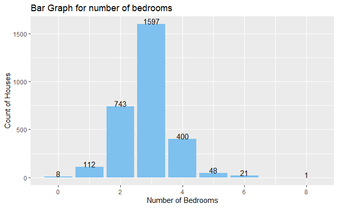

```r
Br <- ames_n %>% count(Bedroom_AbvGr)
Br <- na.omit(Br)

ggplot(Br,
       aes(x = Bedroom_AbvGr,y = n)) +
  geom_bar(stat="identity",fill = "skyblue2")+
  geom_text(aes(label = n), vjust = 0)+
labs(title = "Bar Graph for number of bedrooms",x = "Number of Bedrooms",y = "Count of Houses")
```

Most houses have 3 bedrooms and very rare house with eight bedrooms.

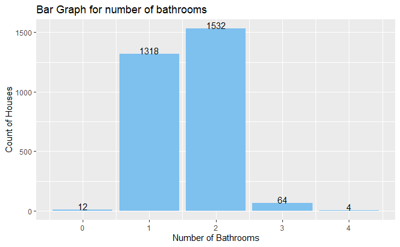

```r
Bt <- ames_n %>% count(Full_Bath)
Bt <- na.omit(Bt)

ggplot(Bt,
       aes(x = Full_Bath,y = n)) +
  geom_bar(stat = "identity",fill = "skyblue2")+
  geom_text(aes(label = n), vjust = 0)+
labs(title = "Bar Graph for number of bathrooms",x = "Number of Bathrooms",y = "Count of Houses")
```

Most houses have 2 bathrooms and only 12 houses with no bathrooms.

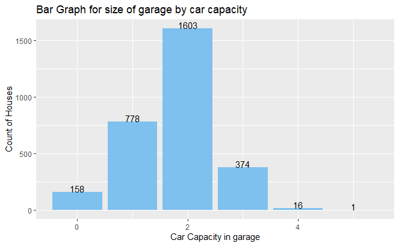

```r
Gc <- ames_n %>% count(Garage_Cars)
Gc <- na.omit(Gc)

ggplot(Gc,
       aes(x = Garage_Cars,y = n)) +
  geom_bar(stat = "identity",fill = "skyblue2")+
  geom_text(aes(label = n), vjust = 0)+
labs(title = "Bar Graph for size of garage by car capacity",x = "Car Capacity in garage",y = "Count of Houses")
```

There are more houses having garage capacity of two cars.

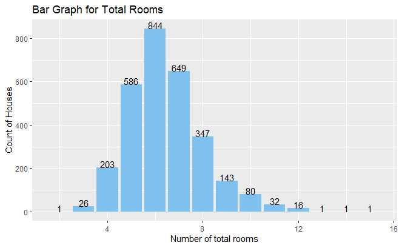

```r
Tr <- ames_n %>% count(TotRms_AbvGrd)
Tr <- na.omit(Tr)

ggplot(Tr,
       aes(x = TotRms_AbvGrd,y = n)) +
  geom_bar(stat = "identity",fill = "skyblue2")+
  geom_text(aes(label = n), vjust = 0)+
labs(title = "Bar Graph for Total Rooms",x = "Number of total rooms",y = "Count of Houses")
```

There are more number of houses with total 6 rooms and the counts of houses declines gradually as the total number of rooms tends to increase.

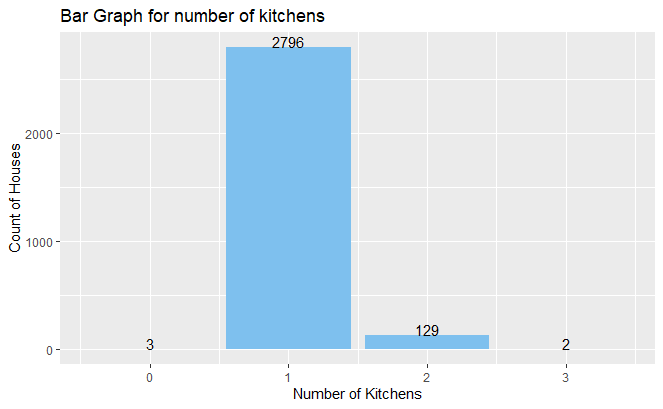

```r
Kt <- ames_n %>% count(Kitchen_AbvGr)
Kt <- na.omit(Kt)

ggplot(Kt,
       aes(x = Kitchen_AbvGr,y = n)) +
  geom_bar(stat="identity",fill = "skyblue2")+
  geom_text(aes(label = n), vjust = 0)+
labs(title = "Bar Graph for number of kitchens",x = "Number of Kitchens",y = "Count of Houses")
```

There are most common houses with 1 kitchen in the house.

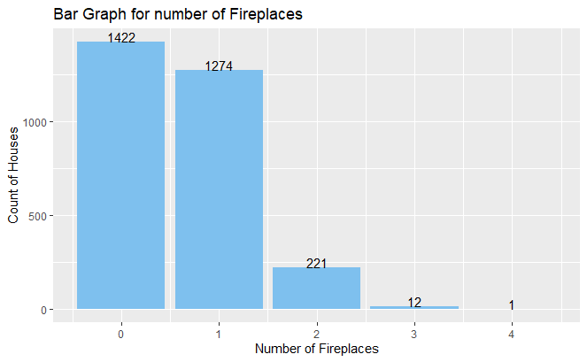

```r
Fp <- ames_n %>% count(Fireplaces)
Fp<- na.omit(Fp)

ggplot(Fp,
       aes(x = Fireplaces,y = n)) +
  geom_bar(stat="identity",fill = "skyblue2")+
  geom_text(aes(label = n), vjust = 0)+
labs(title = "Bar Graph for number of Fireplaces",x = "Number of Fireplaces",y = "Count of Houses")
```

There are many houses with no fireplaces and very few houses have more than 1 fireplace.

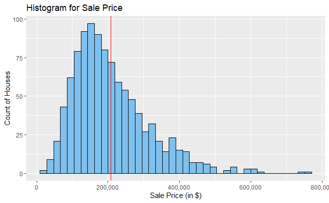

```r
library(ggplot2)

Sp <- ames_n %>% count(Sale_Price)
Sp <- na.omit(Sp)

ggplot(Sp,
       aes(x = Sale_Price)) +
  geom_histogram(fill = "skyblue2",bins=40,color="black")+
  scale_x_continuous(labels = scales::comma)+
  geom_vline(aes(xintercept=mean(Sale_Price)),
             color="red")+
labs(title = "Histogram for Sale Price",x = "Sale Price (in $)",y = "Count of Houses")
```

Graph for Sale Price is right skewed and unimodal.Rising with the amount of $200000, the number of houses declines as it gets expensive.

```r
print(paste0("Mean : ","$", round(mean(Sp$Sale_Price))))
```

```
[1] "Mean : $208065"
```

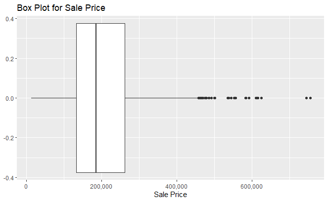

```r
ggplot(Sp,
       aes(x = Sale_Price)) +
  geom_boxplot()+
  scale_x_continuous(labels = scales::comma)+
labs(title = "Box Plot for Sale Price",x = "Sale Price")
```

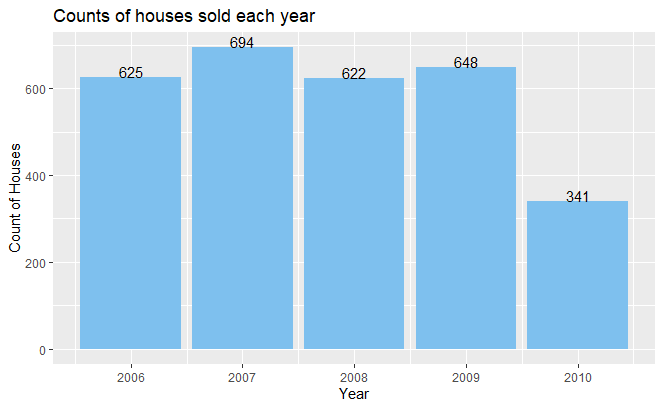

```r
library(ggplot2)
Yr <- ames_n %>% count(Year_Sold)
Yr <- na.omit(Yr)

ggplot(Yr,
       aes(x = Year_Sold,y=n)) +
  geom_col(fill = "skyblue2")+
  geom_text(aes(label = n), vjust = 0)+
labs(title = "Counts of houses sold each year",x = "Year",y = "Count of Houses")
```

From the graph,for the year 2006 and 2008 the sales of houses remains almost same while maximum houses were sold in the year 2007 and the least houses were sold in the year 2010.

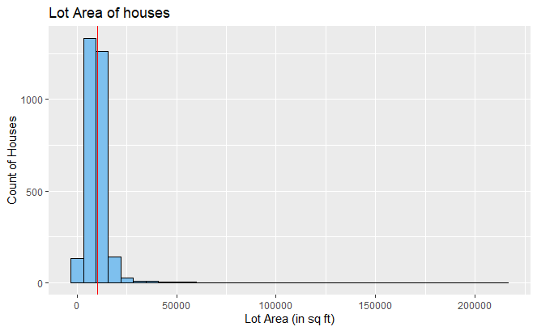

```r
library(ggplot2)
ggplot(ames_n,
       aes(x = Lot_Area)) +
  geom_histogram(fill = "skyblue2",bins=35,color="black")+
  geom_vline(aes(xintercept=mean(Lot_Area)),
             color="red")+
labs(title = "Lot Area of houses ", x = "Lot Area (in sq ft)", y = "Count of Houses")
```

```r
print(paste0("Mean : ", round(mean(ames_n$Lot_Area))," Sq ft"))
```

```
[1] "Mean : 10148 Sq ft"
```

Distribution for lot area of houses is extremely right skewed and most houses have lot sizes less than 50000 square feet.

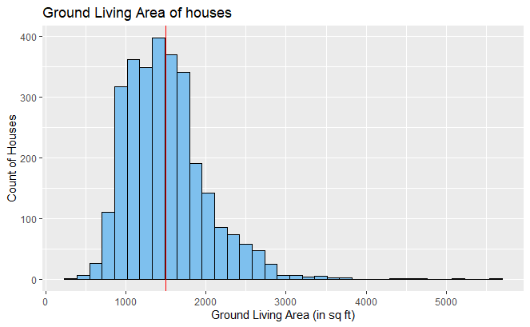

```r
library(ggplot2)
ggplot(ames_n,
       aes(x = Gr_Liv_Area)) +
  geom_histogram(fill = "skyblue2",bins=35,color="black")+
  geom_vline(aes(xintercept=mean(Gr_Liv_Area)),
             color="red")+
labs(title = "Ground Living Area of houses ", x = "Ground Living Area (in sq ft)", y = "Count of Houses")
```

```r
print(paste0("Mean : ", round(mean(ames_n$Gr_Liv_Area)), " Sq ft"))
```

```
[1] "Mean : 1500 Sq ft"
```

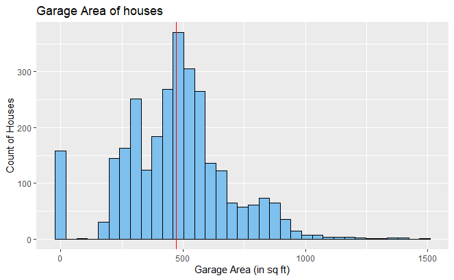

```r
library(ggplot2)
ggplot(ames_n,
       aes(x = Garage_Area)) +
  geom_histogram(fill = "skyblue2",bins=35,color="black")+
  geom_vline(aes(xintercept=mean(Garage_Area)),
             color="red")+
labs(title = "Garage Area of houses ", x = "Garage Area (in sq ft)", y = "Count of Houses")
```

```r
print(paste0("Mean : ", round(mean(ames_n$Garage_Area))," Sq ft"))
```

```
[1] "Mean : 473 Sq ft"
```

The distribution is right skewed and it can be seen that most houses have garage area of nearly 500 sq feet.

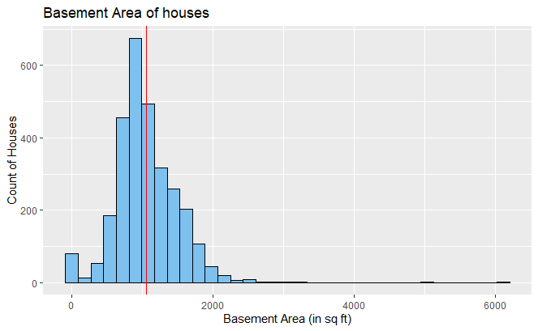

```r
library(ggplot2)
ggplot(ames_n,
       aes(x = Total_Bsmt_SF)) +
  geom_histogram(fill = "skyblue2",bins=35,color="black")+
  geom_vline(aes(xintercept=mean(Total_Bsmt_SF)),
             color="red")+
labs(title = "Basement Area of houses ", x = "Basement Area (in sq ft)", y = "Count of Houses")
```

```r
print(paste0("Mean : ", round(mean(ames_n$Total_Bsmt_SF))," Sq ft"))
```

```
[1] "Mean : 1051 Sq ft"
```

Distribution is unimodal and right skewed.There are many houses that have basement area nearly to 1000 sq feet while few houses do not have basement.

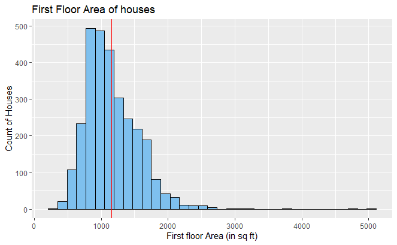

```r
library(ggplot2)
ggplot(ames_n,
       aes(x = First_Flr_SF)) +
  geom_histogram(fill = "skyblue2",bins=35,color="black")+
  geom_vline(aes(xintercept=mean(First_Flr_SF)),
             color="red")+
labs(title = "First Floor Area of houses ", x = "First floor Area (in sq ft)", y = "Count of Houses")
```

```r
print(paste0("Mean : ", round(mean(ames_n$First_Flr_SF))," Sq ft"))
```

```
[1] "Mean : 1160 Sq ft"
```

## Bivariate plots

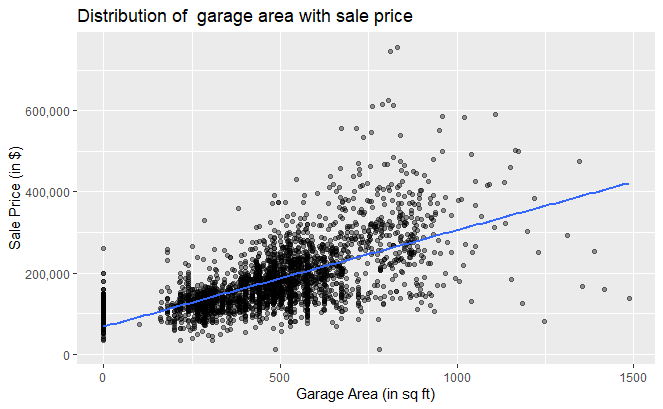

```r
ggplot(ames_n,
       aes(x = Garage_Area, y = Sale_Price)) +
  geom_point(alpha=0.4)+
  scale_y_continuous(labels = scales::comma)+
  geom_smooth(method = "lm", se = F)+
labs(title = "Distribution of  garage area with sale price",x = "Garage Area (in sq ft)",y = "Sale Price (in $)")
```

```r
print(paste0("Correlation : ",cor(ames_n$Sale_Price,ames_n$Garage_Area)))
```

```
[1] "Correlation : 0.640138298487373"
```

Garage area vs sale price shows moderately positive linear relationship. So, as garage area (in sq ft) increases, sales price($) tends to increase.

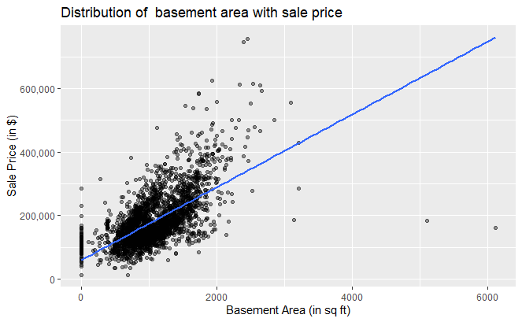

```r
ggplot(ames_n,
       aes(x = Total_Bsmt_SF, y = Sale_Price)) +
  geom_point(alpha=0.4)+
  scale_y_continuous(labels = scales::comma)+
  geom_smooth(method = "lm", se = F)+
labs(title = "Distribution of  basement area with sale price",x = "Basement Area (in sq ft)",y = "Sale Price (in $)")
```

```r
print(paste0("Correlation : ",cor(ames_n$Sale_Price,ames_n$Total_Bsmt_SF)))
```

```
[1] "Correlation : 0.632528849032033"
```

There is a positive,linear relationship between basement area (sq ft) and sale price($).So,as basement area increases, sale price tends to increase.

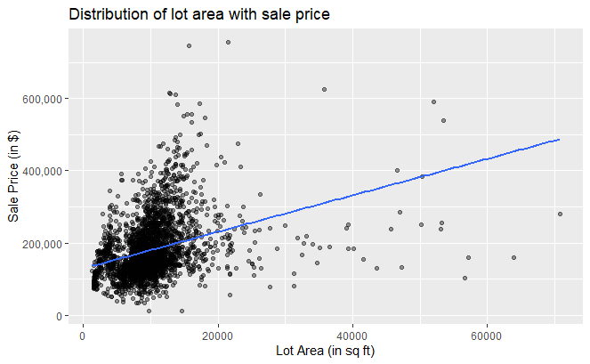

```r
lot_out <- ames %>% filter(Lot_Area<100000)

ggplot(lot_out,
       aes(x = Lot_Area, y = Sale_Price)) +
  geom_point(alpha=0.4)+
  scale_y_continuous(labels = scales::comma)+
  geom_smooth(method = "lm", se = F)+
labs(title = "Distribution of lot area with sale price",x = "Lot Area (in sq ft)",y = "Sale Price (in $)")
```

```r
print(paste0("Correlation : ",cor(lot_out$Sale_Price,lot_out$Lot_Area)))
```

```
[1] "Correlation : 0.336162653460873"
```

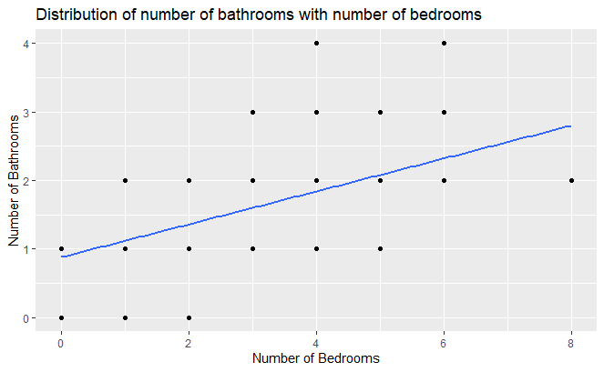

```r
ggplot(ames_n,
       aes(x = Bedroom_AbvGr, y = Full_Bath)) +
  geom_point()+
  geom_smooth(method = "lm", se = F)+
labs(title = "Distribution of number of bathrooms with number of bedrooms",x = "Number of Bedrooms",y = "Number of Bathrooms")
```

```r
print(paste0("Correlation : ", cor(ames_n$Bedroom_AbvGr,ames_n$Full_Bath)))
```

```
[1] "Correlation : 0.359489386123749"
```

The graph between Number of bedrooms and Number of Bathrooms shows linear and slightly positive trend with little weak relationship.

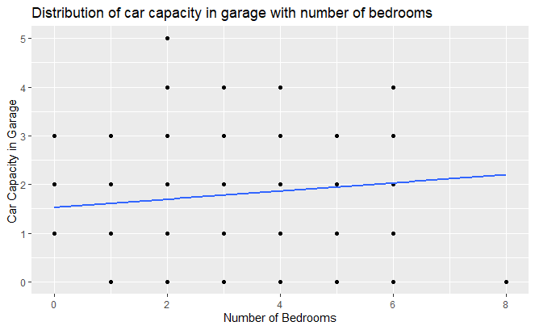

```r
ggplot(ames_n,
       aes(x = Bedroom_AbvGr, y = Garage_Cars)) +
  geom_point()+
labs(title = "Distribution of car capacity in garage with number of bedrooms",x = "Number of Bedrooms",y = "Car Capacity in Garage ")+
geom_smooth(method = "lm", se = F)
```

```r
print(paste0("Correlation : ", cor(ames_n$Bedroom_AbvGr,ames_n$Garage_Cars)))
```

```
[1] "Correlation : 0.0911345944071373"
```

The graph between Number of bedrooms and capacity of cars in garage shows linear and slightly positive trend with weak relationship.

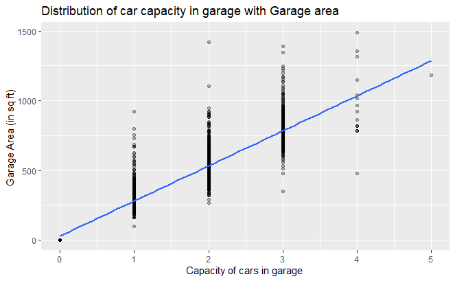

```r
ggplot(ames_n,
       aes(y = Garage_Area, x = Garage_Cars)) +
  geom_point(fill = "skyblue2",alpha=0.3)+
labs(title = "Distribution of car capacity in garage with Garage area",x = "Capacity of cars in garage ",y = "Garage Area (in sq ft) ")+
  geom_smooth(method = "lm", se = F)
```

```r
NA
NA
```

```r
print(paste0("Correlation : ", cor(ames_n$Garage_Area,ames_n$Garage_Cars)))
```

```
[1] "Correlation : 0.889865990244847"
```

The graph between Garage area (in sq ft) and capacity of cars in garage shows linear and positive trend with a strong relationship.

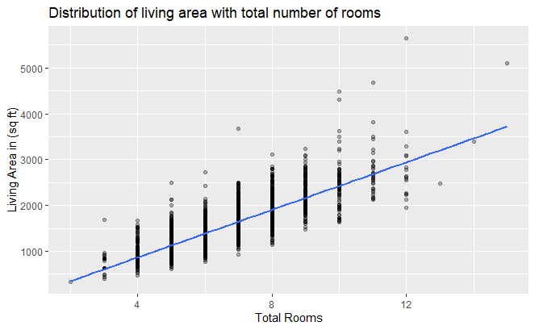

```r
ggplot(ames_n,
       aes(x = TotRms_AbvGrd, y = Gr_Liv_Area)) +
  geom_point(alpha=0.3)+
labs(title = "Distribution of living area with total number of rooms",x = "Total Rooms",y = "Living Area in (sq ft)")+
  geom_smooth(method = "lm", se = F)
```

```r
print(paste0("Correlation : ", cor(ames_n$TotRms_AbvGrd,ames_n$Gr_Liv_Area)))
```

```
[1] "Correlation : 0.80777214489047"
```

The graph between Living area (in sq ft) and total rooms shows linear and positive trend with a strong relationship.

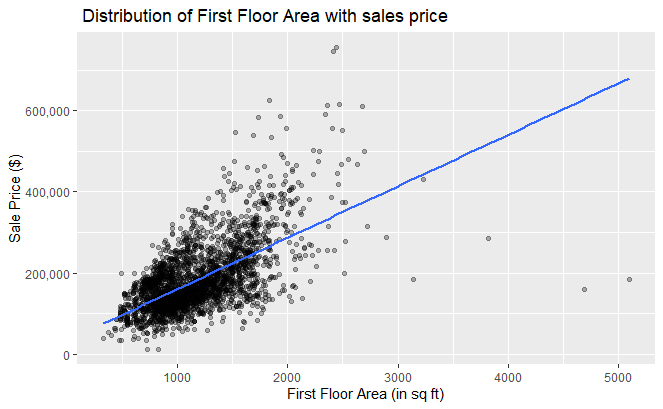

```r
ggplot(ames_n,
       aes(x = First_Flr_SF, y = Sale_Price)) +
  geom_point(alpha=0.3)+
   scale_y_continuous(labels = scales::comma)+
  geom_smooth(method = "lm", se = F)+
labs(title = " Distribution of First Floor Area with sales price ", x = " First Floor Area (in sq ft) ", y = " Sale Price ($) ")
```

```r
print(paste0("Correlation : ", cor(ames_n$First_Flr_SF,ames_n$Sale_Price)))
```

```
[1] "Correlation : 0.621676063270253"
```

```r
kkk <- cor(ames_n)
round(kkk, 2)
```

```
                   Lot_Frontage Lot_Area Year_Built Year_Remod_Add
Lot_Frontage               1.00     0.14       0.03           0.07
Lot_Area                   0.14     1.00       0.02           0.02
Year_Built                 0.03     0.02       1.00           0.61
Year_Remod_Add             0.07     0.02       0.61           1.00
Mas_Vnr_Area               0.11     0.13       0.31           0.19
BsmtFin_SF_1               0.07    -0.05      -0.18          -0.05
BsmtFin_SF_2              -0.01     0.08      -0.03          -0.06
Bsmt_Unf_SF                0.14     0.02       0.13           0.17
Total_Bsmt_SF              0.21     0.25       0.41           0.30
First_Flr_SF               0.24     0.33       0.31           0.24
Second_Flr_SF              0.00     0.03       0.02           0.16
Gr_Liv_Area                0.19     0.29       0.24           0.32
Bsmt_Full_Bath             0.02     0.12       0.21           0.13
Bsmt_Half_Bath            -0.03     0.03      -0.03          -0.05
Full_Bath                  0.08     0.13       0.47           0.46
Half_Bath                 -0.03     0.04       0.27           0.21
Bedroom_AbvGr              0.11     0.14      -0.06          -0.02
Kitchen_AbvGr              0.02    -0.02      -0.14          -0.14
TotRms_AbvGrd              0.20     0.22       0.11           0.20
Fireplaces                 0.05     0.26       0.17           0.13
Garage_Cars                0.14     0.18       0.54           0.42
Garage_Area                0.19     0.21       0.48           0.38
Wood_Deck_SF               0.00     0.16       0.23           0.22
Open_Porch_SF              0.09     0.10       0.20           0.24
Enclosed_Porch             0.02     0.02      -0.37          -0.22
Three_season_porch         0.00     0.02       0.02           0.04
Screen_Porch               0.05     0.06      -0.04          -0.05
Pool_Area                  0.11     0.09       0.00          -0.01
Misc_Val                   0.00     0.07      -0.01           0.00
                   Mas_Vnr_Area BsmtFin_SF_1 BsmtFin_SF_2 Bsmt_Unf_SF
Lot_Frontage               0.11         0.07        -0.01        0.14
Lot_Area                   0.13        -0.05         0.08        0.02
Year_Built                 0.31        -0.18        -0.03        0.13
Year_Remod_Add             0.19        -0.05        -0.06        0.17
Mas_Vnr_Area               1.00        -0.11        -0.01        0.09
BsmtFin_SF_1              -0.11         1.00        -0.12        0.49
BsmtFin_SF_2              -0.01        -0.12         1.00       -0.24
Bsmt_Unf_SF                0.09         0.49        -0.24        1.00
Total_Bsmt_SF              0.39        -0.16         0.09        0.41
```

[output cut: 186 more lines]

```
Half_Bath              0.03    0.00      0.00       0.29     -0.12     0.17
Bedroom_AbvGr          0.00    0.05     -0.02       0.14     -0.04     0.02
Kitchen_AbvGr          0.03    0.04      0.04      -0.12      0.07    -0.07
TotRms_AbvGrd          0.06    0.04     -0.03       0.50     -0.09     0.15
Fireplaces             0.01    0.03     -0.01       0.47     -0.06     0.15
Garage_Cars           -0.02    0.05     -0.02       0.65     -0.22     0.26
Garage_Area            0.01    0.04     -0.01       0.64     -0.21     0.21
Wood_Deck_SF           0.06    0.02      0.00       0.33     -0.14     0.03
Open_Porch_SF          0.08    0.03     -0.04       0.31     -0.10     0.09
Enclosed_Porch         0.01   -0.02      0.00      -0.13      0.14    -0.10
Three_season_porch     0.00    0.03      0.02       0.03      0.02     0.00
Screen_Porch           0.01    0.03     -0.01       0.11      0.05     0.02
Pool_Area              0.01   -0.04     -0.05       0.07      0.00    -0.01
Misc_Val               1.00    0.01      0.01      -0.02      0.01    -0.01
 [ reached getOption("max.print") -- omitted 5 rows ]
```

## Multivariate

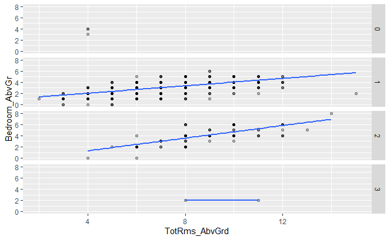

```r
ggplot(data = ames_n,aes(x = TotRms_AbvGrd, y = Bedroom_AbvGr)) +
  geom_point(alpha=0.3) +
  facet_grid(Kitchen_AbvGr ~. )+
  geom_smooth(method = "lm", se = F)
```

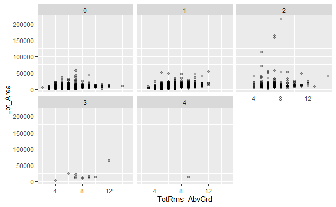

```r
ggplot(data = ames_n) +
  geom_point(mapping = aes(x = TotRms_AbvGrd, y = Lot_Area),alpha=0.3) +
  facet_wrap(~ Fireplaces)
```

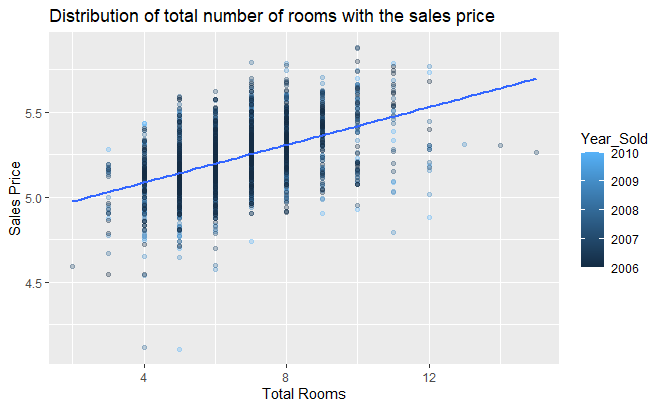

```r
ggplot(ames_n,
       aes(x = TotRms_AbvGrd, y = log10(Sale_Price),color=Year_Sold)) +
  geom_point(alpha=0.3)+
labs(title = "Distribution of total number of rooms with the sales price",x = "Total Rooms",y = "Sales Price")+
  geom_smooth(method = "lm", se = F)
```

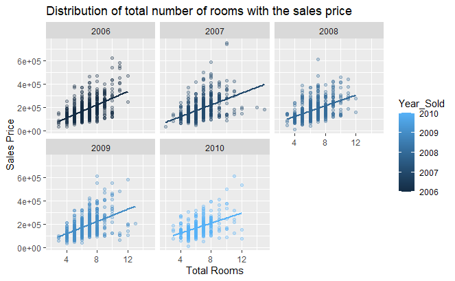

```r
ggplot(ames_n,
       aes(x = TotRms_AbvGrd, y = (Sale_Price),color=Year_Sold) )+
  geom_point(alpha=0.3)+
labs(title = "Distribution of total number of rooms with the sales price",x = "Total Rooms",y = "Sales Price")+
   geom_smooth(method = "lm", se = F)+
   facet_wrap(~Year_Sold )
```

# Response Variable

```r
summary(ames_n$Sale_Price)
```

```
   Min. 1st Qu.  Median    Mean 3rd Qu.    Max.
  12789  129500  160000  180796  213500  755000
```

[figure not shown]

```r
y=rnorm(ames_n$Sale_Price)
hist(y,main="Normal Distribution", col="darkorange")
```

```r
print(paste0("IQR: ", IQR(ames_n$Sale_Price)))
```

```
[1] "IQR: 84000"
```

```r
out = 213500 + 1.5 * (84000)

print(paste0("out = 213500 + 1.5 * (84000) which is ", out))
```

```
[1] "out = 213500 + 1.5 * (84000) which is 339500"
```

Here, Mean > Median so it is right/positive skewed. Moderately skewed.

```r
# print(paste0("Correlation of sale price and year built: ", cor(ames_n$Sale_Price,ames_n$TotRms_AbvGrd)))
#
# print(paste0("Correlation of sale price and total Area: ", cor(ames_n$Sale_Price,ames_n$Lot_Area)))
#
# print(paste0("Correlation of sale price and total Year: ", cor(ames_n$Sale_Price,ames_n$Total_Year)))
```

```r
# tt_cor <- cor(tt_n)
# round(tt_cor, 2)
# options(max.print=1000000)
```

```r
ames_n <- ames_n %>%
  mutate(Total_Area = Gr_Liv_Area+Garage_Area+First_Flr_SF,Total_Bsmt_SF,
         Total_Year = Year_Sold - Year_Remod_Add)
```

# Modeling

```r
tt <- subset(ames_n,ames_n$Sale_Price < 339500)


 tt_n <- ames_n %>%
  mutate(Total_Area = Gr_Liv_Area+Garage_Area+First_Flr_SF,Total_Bsmt_SF,
         Total_Year = Year_Sold - Year_Remod_Add)
```

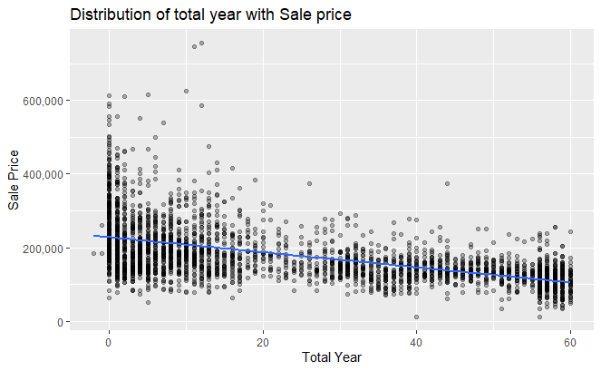

```r
ggplot(tt_n,
       aes(x = Total_Year, y = Sale_Price)) +
  geom_point(alpha=0.3)+
  scale_y_continuous(labels = scales::comma)+
labs(title = "Distribution of total year with Sale price",x = "Total Year",y = "Sale Price")+
  geom_smooth(method = "lm", se = F)
```

```r
NA
```

```r
model1_fit = lm(Sale_Price ~ Total_Year,data = tt_n)

model1_fit
```

```
Call:
lm(formula = Sale_Price ~ Total_Year, data = tt_n)

Coefficients:
(Intercept)   Total_Year
     228991        -2049
```

```r
summary(model1_fit)
```

```
Call:
lm(formula = Sale_Price ~ Total_Year, data = tt_n)

Residuals:
    Min      1Q  Median      3Q     Max
-166747  -40281   -8419   25594  550594

Coefficients:
            Estimate Std. Error t value Pr(>|t|)
(Intercept) 228990.7     1880.0  121.81   <2e-16 ***
Total_Year   -2048.8       59.8  -34.26   <2e-16 ***
---
Signif. codes:  0 ‘***’ 0.001 ‘**’ 0.01 ‘*’ 0.05 ‘.’ 0.1 ‘ ’ 1

Residual standard error: 67510 on 2928 degrees of freedom
Multiple R-squared:  0.2862,    Adjusted R-squared:  0.2859
F-statistic:  1174 on 1 and 2928 DF,  p-value: < 2.2e-16
```

```r
print( paste0("Model : ", "$$", extract_eq(model1_fit), "$$") )
```

```
[1] "Model : $$\\operatorname{Sale\\_Price} = \\alpha + \\beta_{1}(\\operatorname{Total\\_Year}) + \\epsilon$$"
```

```r
#extract_eq(model1_fit)
```

```r
print( paste0("Model Coefs.: ", "$$", extract_eq(model1_fit, use_coefs = TRUE), "$$") )
```

```
[1] "Model Coefs.: $$\\operatorname{\\widehat{Sale\\_Price}} = 228990.67 - 2048.75(\\operatorname{Total\\_Year})$$"
```

```r
#extract_eq(model1_fit, use_coefs = TRUE)
```

As seen from the above data the intercepts of Sale Price and Total Year is estimated 228990.67 which is positive. And , the slope of the linear regression is downwards.

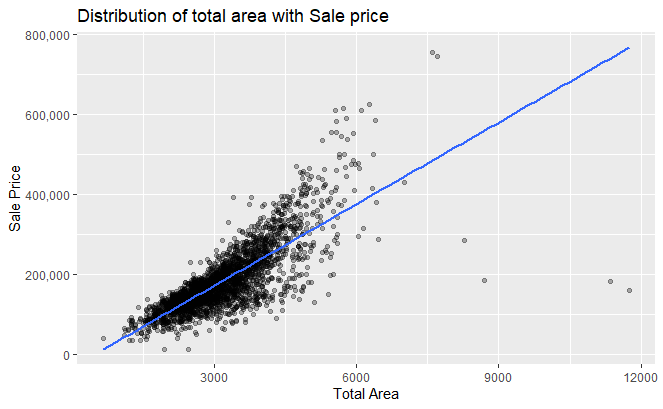

```r
ggplot(tt_n,
       aes(x = Total_Area, y = Sale_Price)) +
  geom_point(alpha=0.3)+
  scale_y_continuous(labels = scales::comma)+
labs(title = "Distribution of total area with Sale price",x = " Total Area ",y = "Sale Price")+
  geom_smooth(method = "lm", se = F)
```

```r
model2_fit = lm(Sale_Price ~ Total_Area,data = tt_n)

model2_fit
```

```
Call:
lm(formula = Sale_Price ~ Total_Area, data = tt_n)

Coefficients:
(Intercept)   Total_Area
  -32539.05        68.12
```

```r
summary(model2_fit)
```

```
Call:
lm(formula = Sale_Price ~ Total_Area, data = tt_n)

Residuals:
    Min      1Q  Median      3Q     Max
-607968  -21337    1882   22479  270397

Coefficients:
              Estimate Std. Error t value Pr(>|t|)
(Intercept) -3.254e+04  3.153e+03  -10.32   <2e-16 ***
Total_Area   6.812e+01  9.651e-01   70.58   <2e-16 ***
---
Signif. codes:  0 ‘***’ 0.001 ‘**’ 0.01 ‘*’ 0.05 ‘.’ 0.1 ‘ ’ 1

Residual standard error: 48610 on 2928 degrees of freedom
Multiple R-squared:  0.6298,    Adjusted R-squared:  0.6297
F-statistic:  4982 on 1 and 2928 DF,  p-value: < 2.2e-16
```

```r
# extract_eq(model2_fit)
#
# extract_eq(model2_fit, use_coefs = TRUE)
```

```r
print( paste0("Model : ", "$$", extract_eq(model2_fit), "$$") )
```

```
[1] "Model : $$\\operatorname{Sale\\_Price} = \\alpha + \\beta_{1}(\\operatorname{Total\\_Area}) + \\epsilon$$"
```

```r
#extract_eq(model1_fit)
```

```r
print( paste0("Model Coefs.: ", "$$", extract_eq(model2_fit, use_coefs = TRUE), "$$") )
```

```
[1] "Model Coefs.: $$\\operatorname{\\widehat{Sale\\_Price}} = -32539.05 + 68.12(\\operatorname{Total\\_Area})$$"
```

```r
#extract_eq(model1_fit, use_coefs = TRUE)
```

As seen from the above data the intercepts of Sale Price and Total Area is estimated -32539.05 which is negative And , the slope of the linear regression is upwards.

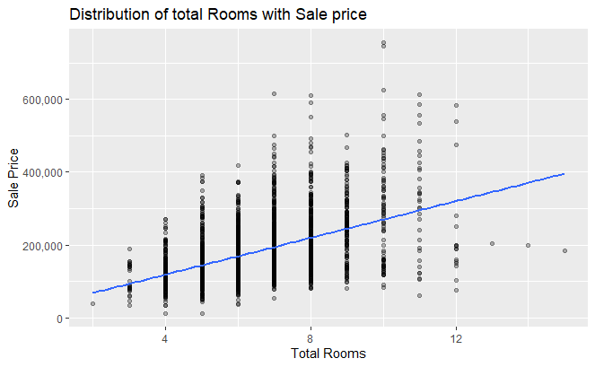

```r
ggplot(tt_n,
       aes(x = TotRms_AbvGrd, y = Sale_Price)) +
  geom_point(alpha=0.3)+
  scale_y_continuous(labels = scales::comma)+
labs(title = "Distribution of total Rooms with Sale price",x = "Total Rooms",y = "Sale Price")+
  geom_smooth(method = "lm", se = F)
```

```r
model3_fit = lm(Sale_Price ~ TotRms_AbvGrd,data = tt_n)

model3_fit
```

```
Call:
lm(formula = Sale_Price ~ TotRms_AbvGrd, data = tt_n)

Coefficients:
  (Intercept)  TotRms_AbvGrd
        18665          25164
```

```r
summary(model3_fit)
```

```
Call:
lm(formula = Sale_Price ~ TotRms_AbvGrd, data = tt_n)

Residuals:
    Min      1Q  Median      3Q     Max
-244131  -39148  -10680   30188  484696

Coefficients:
              Estimate Std. Error t value Pr(>|t|)
(Intercept)    18665.4     5407.0   3.452 0.000564 ***
TotRms_AbvGrd  25163.8      815.3  30.866  < 2e-16 ***
---
Signif. codes:  0 ‘***’ 0.001 ‘**’ 0.01 ‘*’ 0.05 ‘.’ 0.1 ‘ ’ 1

Residual standard error: 69400 on 2928 degrees of freedom
Multiple R-squared:  0.2455,    Adjusted R-squared:  0.2452
F-statistic: 952.7 on 1 and 2928 DF,  p-value: < 2.2e-16
```

```r
# extract_eq(model3_fit)
#
# extract_eq(model3_fit, use_coefs = TRUE)
```

```r
print( paste0("Model : ", "$$", extract_eq(model3_fit), "$$") )
```

```
[1] "Model : $$\\operatorname{Sale\\_Price} = \\alpha + \\beta_{1}(\\operatorname{TotRms\\_AbvGrd}) + \\epsilon$$"
```

```r
print( paste0("Model Coefs.: ", "$$", extract_eq(model3_fit, use_coefs = TRUE), "$$") )
```

```
[1] "Model Coefs.: $$\\operatorname{\\widehat{Sale\\_Price}} = 18665.4 + 25163.83(\\operatorname{TotRms\\_AbvGrd})$$"
```

As seen from the above data the intercepts of Sale Price and Total Rooms is estimated 18665.4 which is positive And , the slope of the linear regression is upwards.

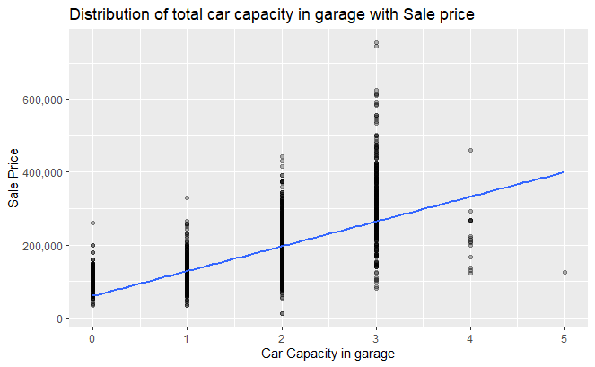

```r
ggplot(tt_n,
       aes(x = Garage_Cars, y = Sale_Price)) +
  geom_point(alpha=0.3)+
  scale_y_continuous(labels = scales::comma)+
labs(title = "Distribution of total car capacity in garage with Sale price",x = "Car Capacity in garage",y = "Sale Price")+
  geom_smooth(method = "lm", se = F)
```

```r
model4_fit = lm(Sale_Price ~ Garage_Cars,data = tt_n)

broom::tidy(model4_fit)
```

| term | estimate | std.error | statistic | p.value |
| --- | --- | --- | --- | --- |
| (Intercept) | 60753.40 | 2842.558 | 21.37279 | 2.673115e-94 |
| Garage_Cars | 67966.18 | 1478.048 | 45.98373 | 0.000000e+00 |

```r
model4_fit
```

Call: lm(formula = Sale_Price ~ Garage_Cars, data = tt_n)

Coefficients: (Intercept) Garage_Cars  
60753 67966

```r
summary(model4_fit)
```

Call: lm(formula = Sale_Price ~ Garage_Cars, data = tt_n)

Residuals: Min 1Q Median 3Q Max -274084 -36686 -6686 25306 490348

Residual standard error: 60890 on 2928 degrees of freedom Multiple R-squared: 0.4193, Adjusted R-squared: 0.4191 F-statistic: 2115 on 1 and 2928 DF, p-value: < 2.2e-16

```r
#extract_eq(model4_fit)
print( paste0("Model : ", "$$", extract_eq(model4_fit), "$$") )
```

[1] “Model :
$$\\operatorname{Sale\\_Price} = \\alpha + \\beta_{1}(\\operatorname{Garage\\_Cars}) + \\epsilon$$
”

```r
print( paste0("Model Coefs.: ", "$$", extract_eq(model4_fit, use_coefs = TRUE), "$$") )
```

[1] “Model Coefs.:
$$\\operatorname{\\widehat{Sale\\_Price}} = 60753.4 + 67966.18(\\operatorname{Garage\\_Cars})$$
”

```r
#extract_eq(model4_fit, use_coefs = TRUE)
```

As seen from the above data the intercepts of Sale Price and Car Capacity in garage is estimated 60753 which is positive And , the slope of the linear regression is upwards.

## Model Assessment

Assessing our models to get the best one.

```r
library(modelsummary)

models <- list(model1_fit,model2_fit,model3_fit)

modelsummary(models)
```

|  | Model 1 | Model 2 | Model 3 |
| --- | --- | --- | --- |
| (Intercept) | 228990.669 | -32539.047 | 18665.403 |
|  | (1879.952) | (3153.083) | (5407.004) |
| Total_Year | -2048.752 |  |  |
|  | (59.800) |  |  |
| Total_Area |  | 68.117 |  |
|  |  | (0.965) |  |
| TotRms_AbvGrd |  |  | 25163.832 |
|  |  |  | (815.269) |
| Num.Obs. | 2930 | 2930 | 2930 |
| R2 | 0.286 | 0.630 | 0.245 |
| R2 Adj. | 0.286 | 0.630 | 0.245 |
| AIC | 73482.1 | 71558.0 | 73644.4 |
| BIC | 73500.0 | 71575.9 | 73662.4 |
| Log.Lik. | -36738.050 | -35775.982 | -36819.217 |
| F | 1173.765 | 4981.931 | 952.689 |